# Week 7 - Lectures & Quick Questions

Vishal Gupta

4/9/2019

```r
library(ggplot2)
```

## Visualizing the World: An Introduction to Visualization

#### Video 4: Basic Scatterplots Using ggplot

Loading the WHO data

```r
WHO = read.csv("~/Downloads/WHO.csv")
str(WHO)
```

```
## 'data.frame':    194 obs. of  13 variables:
##  $ Country                      : Factor w/ 194 levels "Afghanistan",..: 1 2 3 4 5 6 7 8 9 10 ...
##  $ Region                       : Factor w/ 6 levels "Africa","Americas",..: 3 4 1 4 1 2 2 4 6 4 ...
##  $ Population                   : int  29825 3162 38482 78 20821 89 41087 2969 23050 8464 ...
##  $ Under15                      : num  47.4 21.3 27.4 15.2 47.6 ...
##  $ Over60                       : num  3.82 14.93 7.17 22.86 3.84 ...
##  $ FertilityRate                : num  5.4 1.75 2.83 NA 6.1 2.12 2.2 1.74 1.89 1.44 ...
##  $ LifeExpectancy               : int  60 74 73 82 51 75 76 71 82 81 ...
##  $ ChildMortality               : num  98.5 16.7 20 3.2 163.5 ...
##  $ CellularSubscribers          : num  54.3 96.4 99 75.5 48.4 ...
##  $ LiteracyRate                 : num  NA NA NA NA 70.1 99 97.8 99.6 NA NA ...
##  $ GNI                          : num  1140 8820 8310 NA 5230 ...
##  $ PrimarySchoolEnrollmentMale  : num  NA NA 98.2 78.4 93.1 91.1 NA NA 96.9 NA ...
##  $ PrimarySchoolEnrollmentFemale: num  NA NA 96.4 79.4 78.2 84.5 NA NA 97.5 NA ...
```

Plotting with `plot`

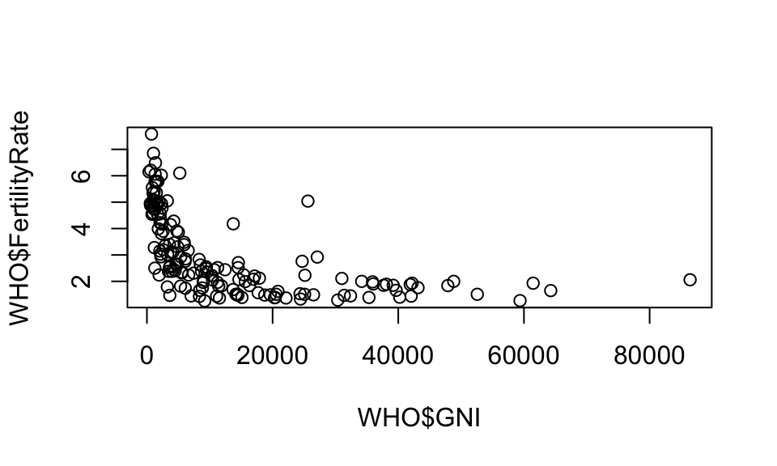

```r
plot(WHO$GNI,WHO$FertilityRate)
```

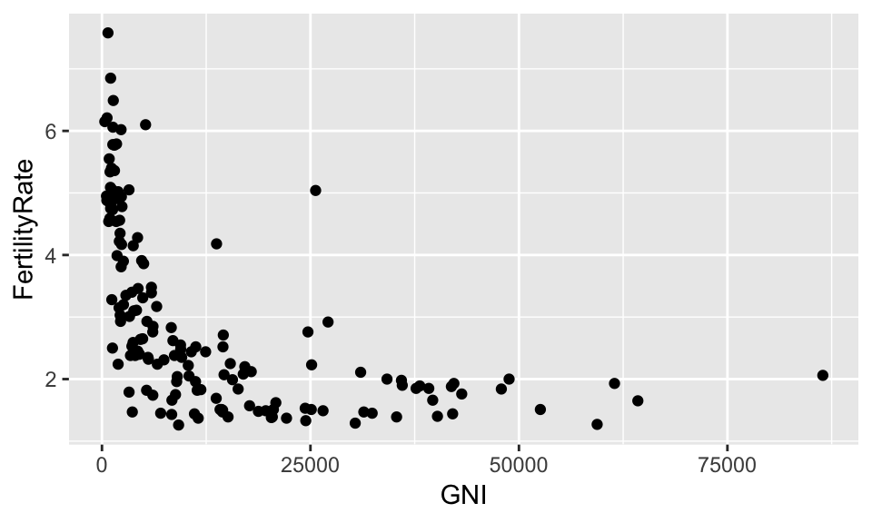

```r
scatterplot = ggplot(WHO, aes(x=GNI,y=FertilityRate))
scatterplot + geom_point()
```

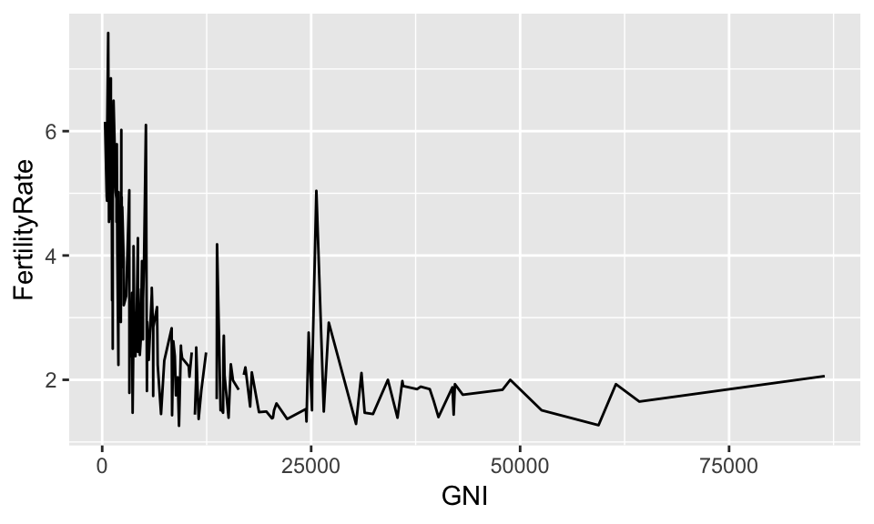

```r
scatterplot + geom_line()
```

Changing colors and shapes

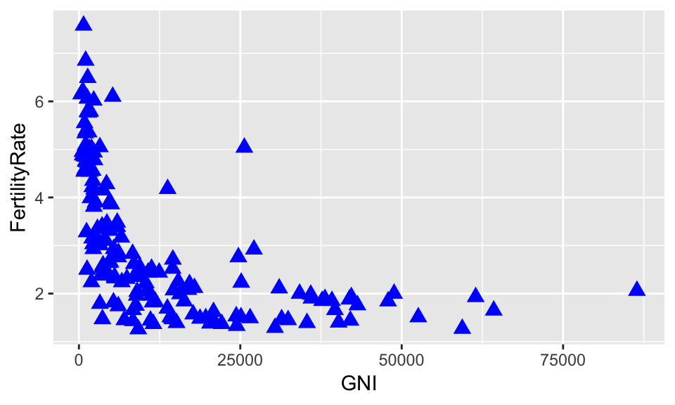

```r
scatterplot + geom_point(color = "blue", size = 3, shape = 17)
```

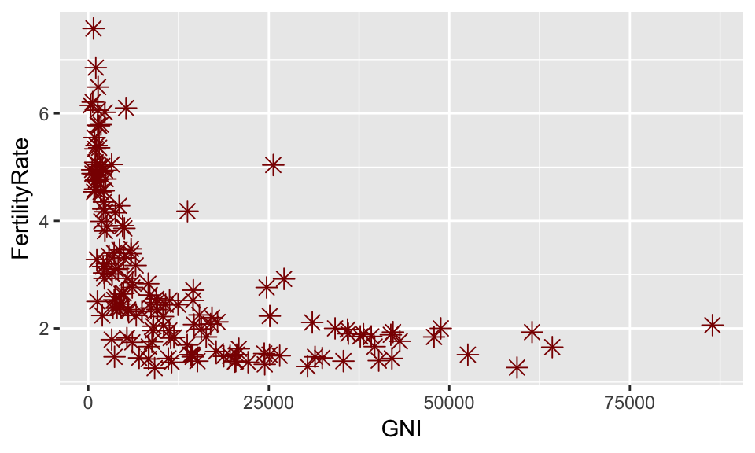

```r
scatterplot + geom_point(color = "darkred", size = 3, shape = 8)
```

Changing title

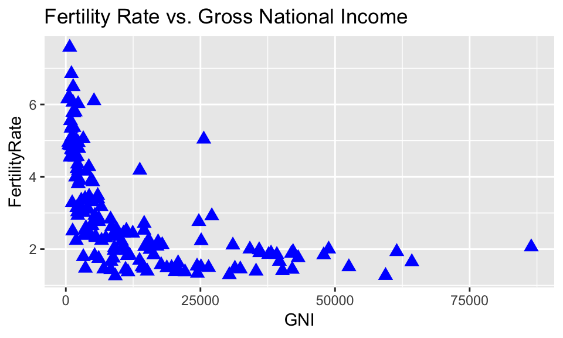

```r
scatterplot + geom_point(colour = "blue", size = 3, shape = 17) + ggtitle("Fertility Rate vs. Gross National Income")
```

Printing plit to pdf

```r
fertilityGNIplot = scatterplot + geom_point(colour = "blue", size = 3, shape = 17) + ggtitle("Fertility Rate vs. Gross National Income")
pdf("MyPlot.pdf")
print(fertilityGNIplot)
dev.off()
```

#### Quick Question

In R, change the shape of your points to the number 15. What shape are the points now?

- Circles
- Diamonds
- Crosses
- **Squares**
- Stars

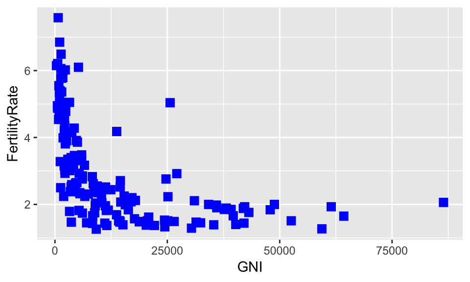

```r
scatterplot + geom_point(color = "blue", size = 3, shape = 15)
```

#### Video 5 - More advanced Scatterplots

Color the points by region

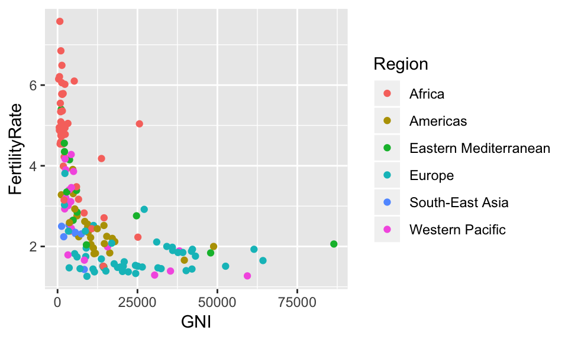

```r
ggplot(WHO, aes(x = GNI, y = FertilityRate, color = Region)) + geom_point()
```

Color the points according to life expectancy

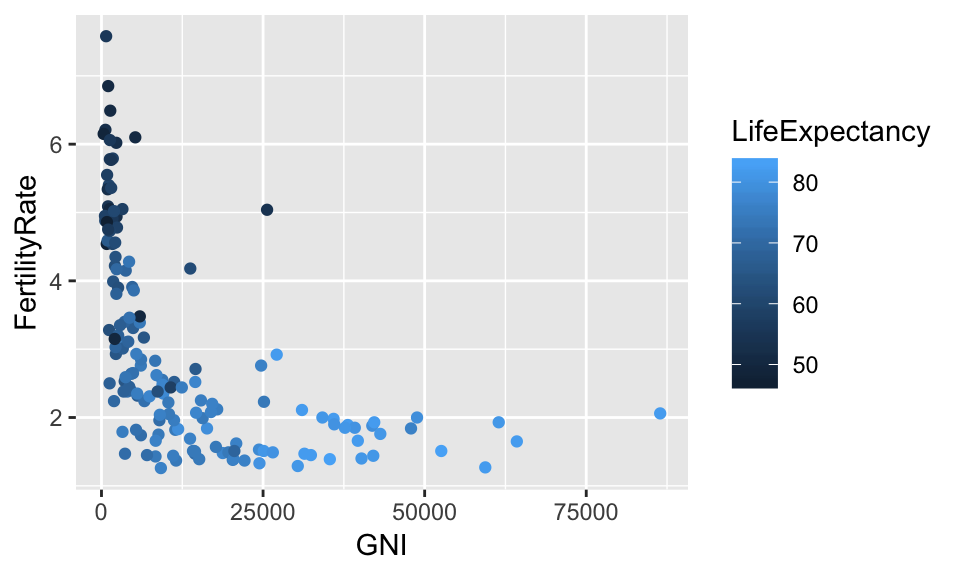

```r
ggplot(WHO, aes(x = GNI, y = FertilityRate, color = LifeExpectancy)) + geom_point()
```

Using fertility rate to predict percentage of the population under 15.

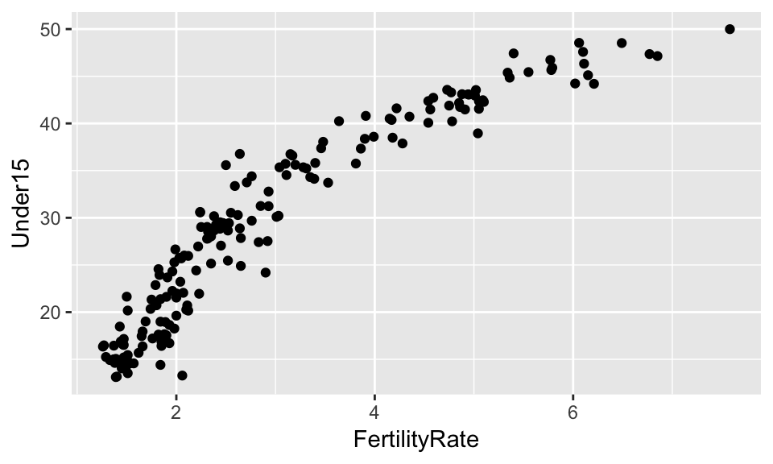

```r
ggplot(WHO, aes(x = FertilityRate, y = Under15)) + geom_point()
```

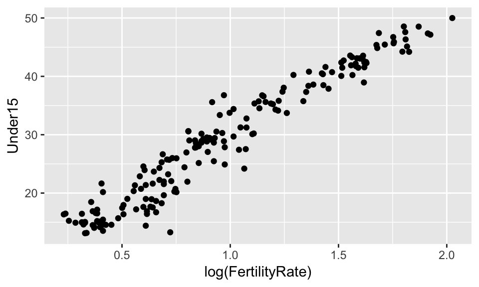

```r
ggplot(WHO, aes(x = log(FertilityRate), y = Under15)) + geom_point()
```

Using a Linear regression model to predict the percentage of the population under 15, using the log of the fertility rate.

```r
mod = lm(Under15 ~ log(FertilityRate), data = WHO)
summary(mod)
```

```
##
## Call:
## lm(formula = Under15 ~ log(FertilityRate), data = WHO)
##
## Residuals:
##      Min       1Q   Median       3Q      Max
## -10.3131  -1.7742   0.0446   1.7440   7.7174
##
## Coefficients:
##                    Estimate Std. Error t value Pr(>|t|)
## (Intercept)          7.6540     0.4478   17.09   <2e-16 ***
## log(FertilityRate)  22.0547     0.4175   52.82   <2e-16 ***
## ---
## Signif. codes:  0 '***' 0.001 '**' 0.01 '*' 0.05 '.' 0.1 ' ' 1
##
## Residual standard error: 2.65 on 181 degrees of freedom
##   (11 observations deleted due to missingness)
## Multiple R-squared:  0.9391, Adjusted R-squared:  0.9387
## F-statistic:  2790 on 1 and 181 DF,  p-value: < 2.2e-16
```

Adding regression line to the plot

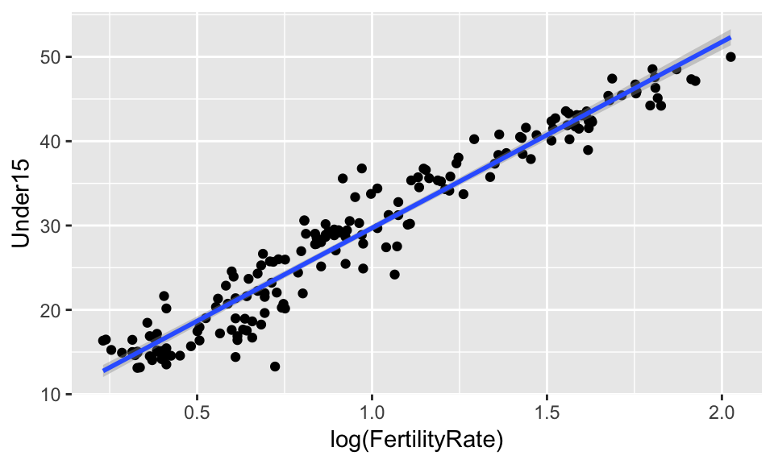

```r
ggplot(WHO, aes(x = log(FertilityRate), y = Under15)) + geom_point() + stat_smooth(method = "lm")
```

PLotting regression line with 99% confidence interval

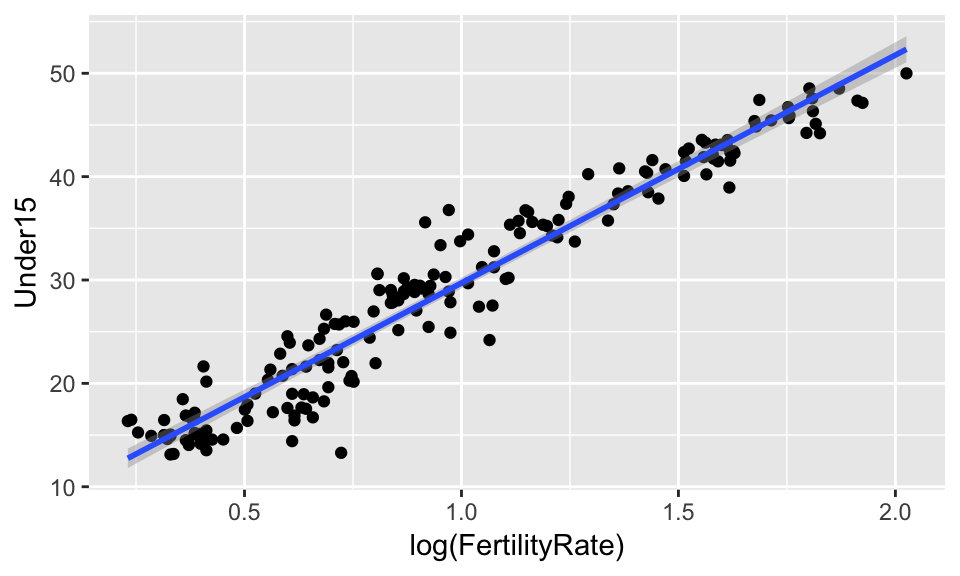

```r
ggplot(WHO, aes(x = log(FertilityRate), y = Under15)) + geom_point() + stat_smooth(method = "lm", level = 0.99)
```

PLotting regression line without confidence interval

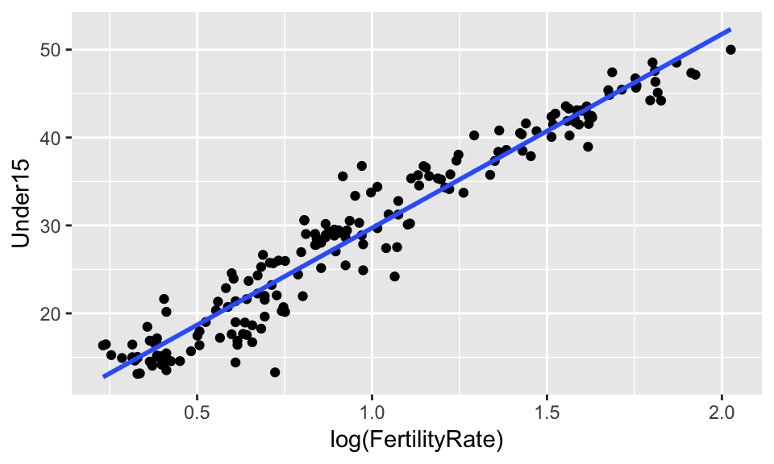

```r
ggplot(WHO, aes(x = log(FertilityRate), y = Under15)) + geom_point() + stat_smooth(method = "lm", se = FALSE)
```

Change the color of the regression line

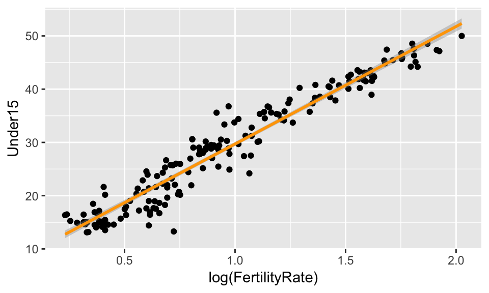

```r
ggplot(WHO, aes(x = log(FertilityRate), y = Under15)) + geom_point() + stat_smooth(method = "lm", colour = "orange")
```

#### Quick Question

Create the fertility rate versus population under 15 plot again:

```
ggplot(WHO, aes(x = FertilityRate, y = Under15)) + geom_point()
```

Now, color the points by the Region variable. One region in particular has a lot of countries with a very low fertility rate and a very low percentage of the population under 15. Which region is it?

- Africa
- Americas
- Eastern Mediterranean
- **Europe**
- South-East Asia
- Western Pacific

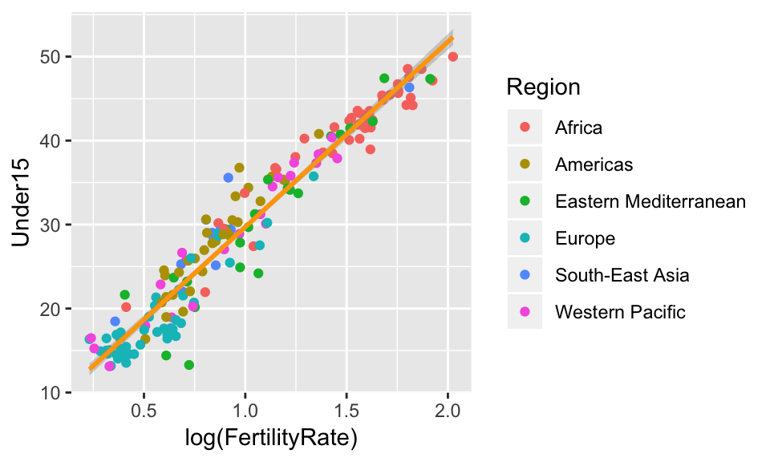

```r
ggplot(WHO, aes(x = log(FertilityRate), y = Under15, color = Region)) + geom_point() + stat_smooth(method = "lm", colour = "orange")
```

## Predictive Policing

#### Video 3 - A Basic Line Plot

Load data

```r
mvt = read.csv("~/Downloads/mvt.csv", stringsAsFactors=FALSE)
str(mvt)
```

```
## 'data.frame':    191641 obs. of  3 variables:
##  $ Date     : chr  "12/31/12 23:15" "12/31/12 22:00" "12/31/12 22:00" "12/31/12 22:00" ...
##  $ Latitude : num  41.8 41.9 42 41.8 41.8 ...
##  $ Longitude: num  -87.6 -87.7 -87.8 -87.7 -87.6 ...
```

Convert the Date variable to a format that R will recognize

```r
mvt$Date = strptime(mvt$Date, format="%m/%d/%y %H:%M")
```

Extract the hour and the day of the week

```r
mvt$Weekday = weekdays(mvt$Date)
mvt$Hour = mvt$Date$hour
str(mvt)
```

```
## 'data.frame':    191641 obs. of  5 variables:
##  $ Date     : POSIXlt, format: "2012-12-31 23:15:00" "2012-12-31 22:00:00" ...
##  $ Latitude : num  41.8 41.9 42 41.8 41.8 ...
##  $ Longitude: num  -87.6 -87.7 -87.8 -87.7 -87.6 ...
##  $ Weekday  : chr  "Monday" "Monday" "Monday" "Monday" ...
##  $ Hour     : int  23 22 22 22 21 20 20 20 19 18 ...
```

Simple line plot - Total number of crimes on each day of the week

```r
table(mvt$Weekday)
```

```
##
##    Friday    Monday  Saturday    Sunday  Thursday   Tuesday Wednesday
##     29284     27397     27118     26316     27319     26791     27416
```

```r
WeekdayCounts = as.data.frame(table(mvt$Weekday))
str(WeekdayCounts)
```

```
## 'data.frame':    7 obs. of  2 variables:
##  $ Var1: Factor w/ 7 levels "Friday","Monday",..: 1 2 3 4 5 6 7
##  $ Freq: int  29284 27397 27118 26316 27319 26791 27416
```

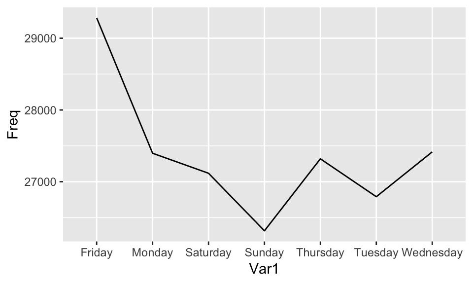

```r
ggplot(WeekdayCounts, aes(x=Var1, y=Freq)) + geom_line(aes(group=1))
```

Make the “Var1” variable an ORDERED factor variable of Days

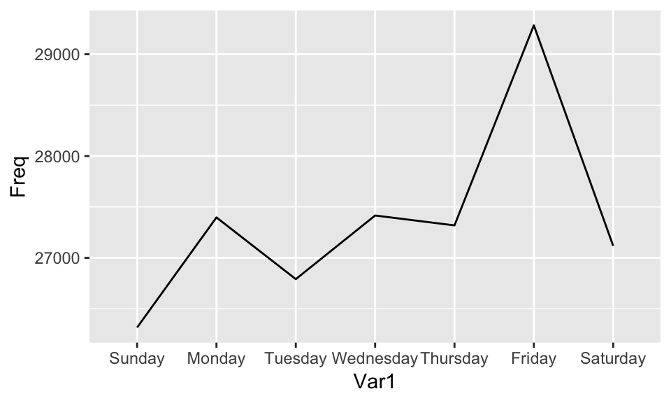

```r
WeekdayCounts$Var1 = factor(WeekdayCounts$Var1, ordered=TRUE, levels=c("Sunday", "Monday", "Tuesday", "Wednesday", "Thursday", "Friday","Saturday"))
ggplot(WeekdayCounts, aes(x=Var1, y=Freq)) + geom_line(aes(group=1))
```

Change x and y labels

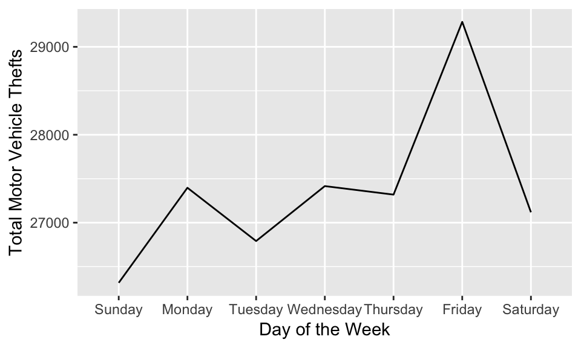

```r
ggplot(WeekdayCounts, aes(x=Var1, y=Freq)) + geom_line(aes(group=1)) + xlab("Day of the Week") + ylab("Total Motor Vehicle Thefts")
```

#### Quick Question

Create a new line plot, like the one in Video 3, but add the argument “linetype=2”. So the geom_line part of the plotting command should look like:

```
geom_line(aes(group=1), linetype=2)
```

What does this do?

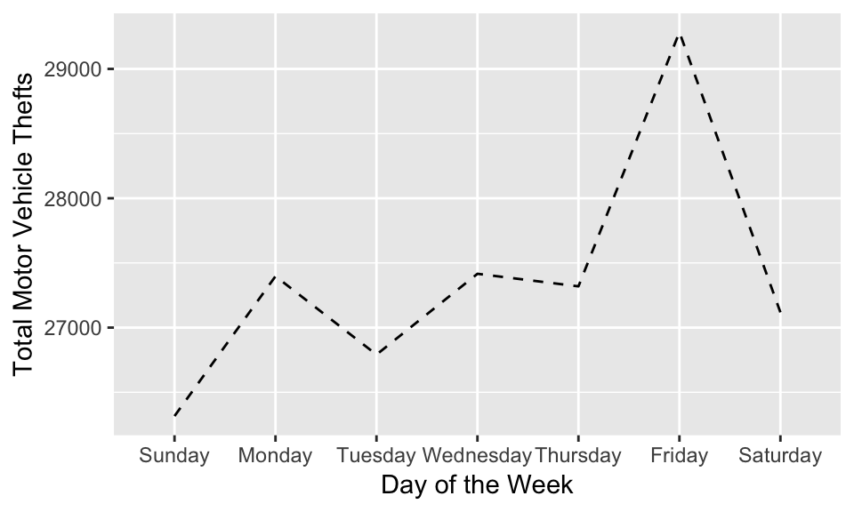

```r
ggplot(WeekdayCounts, aes(x=Var1, y=Freq)) + geom_line(aes(group=1), linetype=2) + xlab("Day of the Week") + ylab("Total Motor Vehicle Thefts")
```

- Makes the line thicker
- Changes the color of the line to blue
- **Makes the line dashed**
- Makes the line lighter in color

Now, change the alpha parameter to 0.3 by replacing “linetype=2” with “alpha=0.3” in the plot command. What does this do?

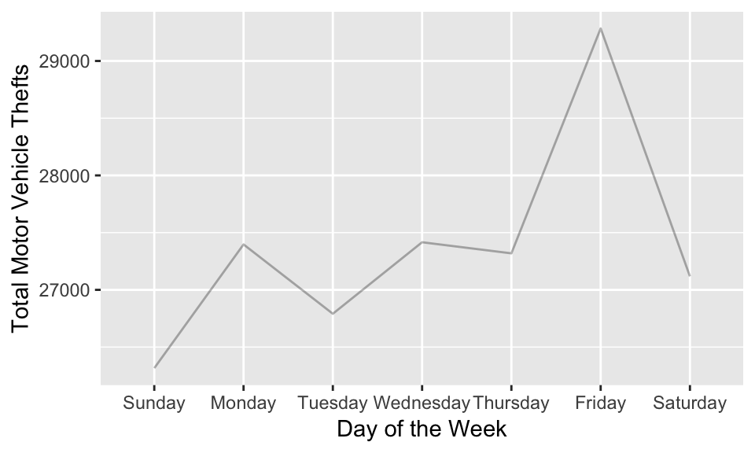

```r
ggplot(WeekdayCounts, aes(x=Var1, y=Freq)) + geom_line(aes(group=1), alpha=0.3) + xlab("Day of the Week") + ylab("Total Motor Vehicle Thefts")
```

- Makes the line thicker
- Changes the color of the line to blue
- Makes the line dashed
- **Makes the line lighter in color**

#### Video 4 - Adding the Hour of the Day

Create a counts table for the weekday and hour

```r
table(mvt$Weekday, mvt$Hour)
```

```
##
##                0    1    2    3    4    5    6    7    8    9   10   11
##   Friday    1873  932  743  560  473  602  839 1203 1268 1286  938  822
##   Monday    1900  825  712  527  415  542  772 1123 1323 1235  971  737
##   Saturday  2050 1267  985  836  652  508  541  650  858 1039  946  789
##   Sunday    2028 1236 1019  838  607  461  478  483  615  864  884  787
##   Thursday  1856  816  696  508  400  534  799 1135 1298 1301  932  731
##   Tuesday   1691  777  603  464  414  520  845 1118 1175 1174  948  786
##   Wednesday 1814  790  619  469  396  561  862 1140 1329 1237  947  763
##
##               12   13   14   15   16   17   18   19   20   21   22   23
##   Friday    1207  857  937 1140 1165 1318 1623 1652 1736 1881 2308 1921
##   Monday    1129  824  958 1059 1136 1252 1518 1503 1622 1815 2009 1490
##   Saturday  1204  767  963 1086 1055 1084 1348 1390 1570 1702 2078 1750
##   Sunday    1192  789  959 1037 1083 1160 1389 1342 1706 1696 2079 1584
##   Thursday  1093  752  831 1044 1131 1258 1510 1537 1668 1776 2134 1579
##   Tuesday   1108  762  908 1071 1090 1274 1553 1496 1696 1816 2044 1458
##   Wednesday 1225  804  863 1075 1076 1289 1580 1507 1718 1748 2093 1511
```

```r
DayHourCounts = as.data.frame(table(mvt$Weekday, mvt$Hour))
str(DayHourCounts)
```

```
## 'data.frame':    168 obs. of  3 variables:
##  $ Var1: Factor w/ 7 levels "Friday","Monday",..: 1 2 3 4 5 6 7 1 2 3 ...
##  $ Var2: Factor w/ 24 levels "0","1","2","3",..: 1 1 1 1 1 1 1 2 2 2 ...
##  $ Freq: int  1873 1900 2050 2028 1856 1691 1814 932 825 1267 ...
```

Convert the second variable, Var2, to numbers and call it Hour

```r
DayHourCounts$Hour = as.numeric(as.character(DayHourCounts$Var2))
```

Create plot

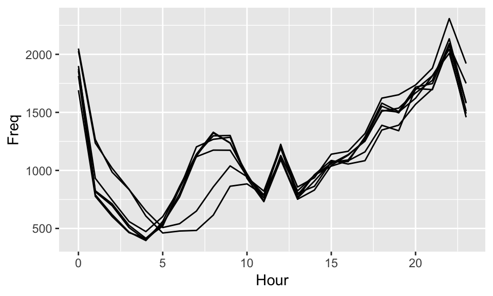

```r
ggplot(DayHourCounts, aes(x=Hour, y=Freq)) + geom_line(aes(group=Var1))
```

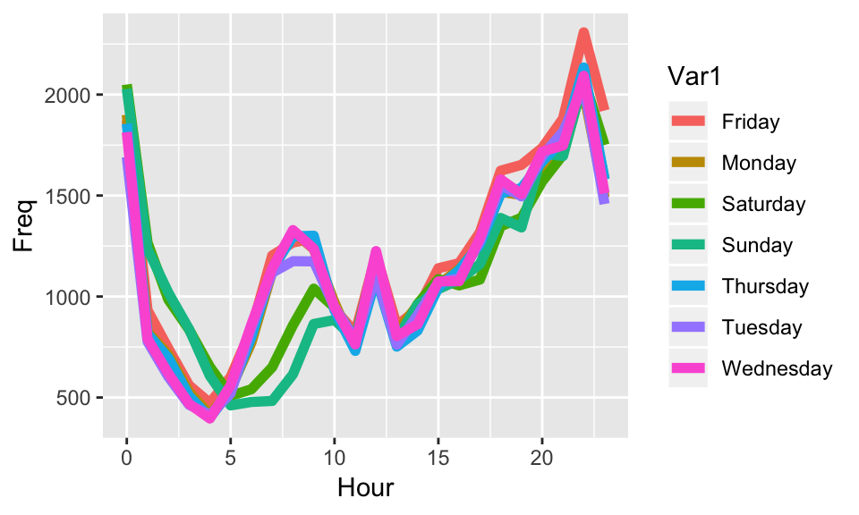

```r
ggplot(DayHourCounts, aes(x=Hour, y=Freq)) + geom_line(aes(group=Var1, color=Var1), size=2)
```

Separate the weekends from the weekdays

```r
DayHourCounts$Type = ifelse((DayHourCounts$Var1 == "Sunday") | (DayHourCounts$Var1 == "Saturday"), "Weekend", "Weekday")
```

Redo the plot, this time coloring by Type

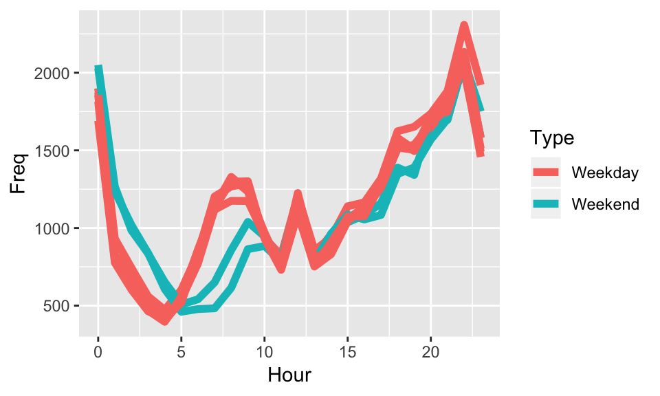

```r
ggplot(DayHourCounts, aes(x=Hour, y=Freq)) + geom_line(aes(group=Var1, color=Type), size=2)
```

Make the lines a little transparent

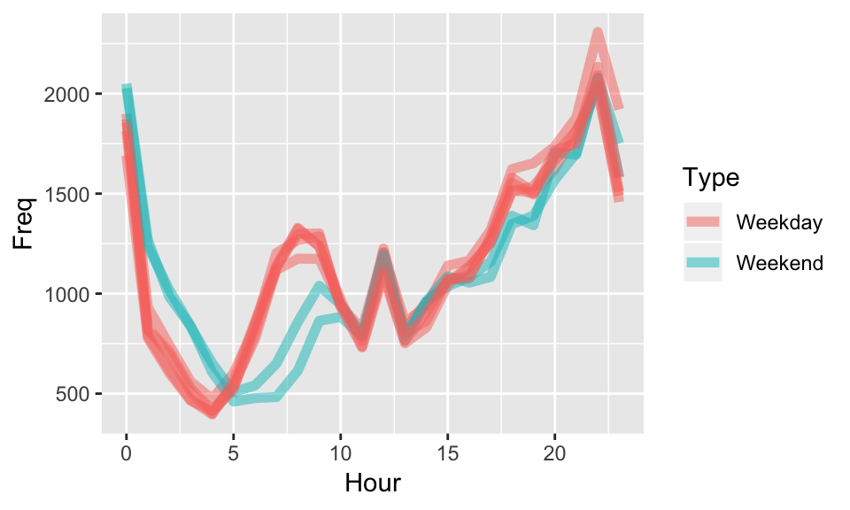

```r
ggplot(DayHourCounts, aes(x=Hour, y=Freq)) + geom_line(aes(group=Var1, color=Type), size=2, alpha=0.5)
```

Fix the order of the days:

```r
DayHourCounts$Var1 = factor(DayHourCounts$Var1, ordered=TRUE, levels=c("Monday", "Tuesday", "Wednesday", "Thursday", "Friday", "Saturday", "Sunday"))
```

Make a heatmap

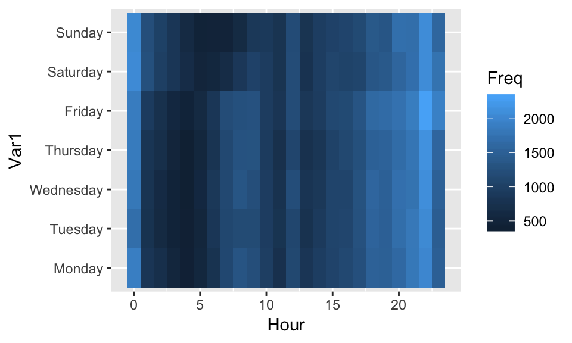

```r
ggplot(DayHourCounts, aes(x = Hour, y = Var1)) + geom_tile(aes(fill = Freq))
```

Change the label on the legend, and get rid of the y-label

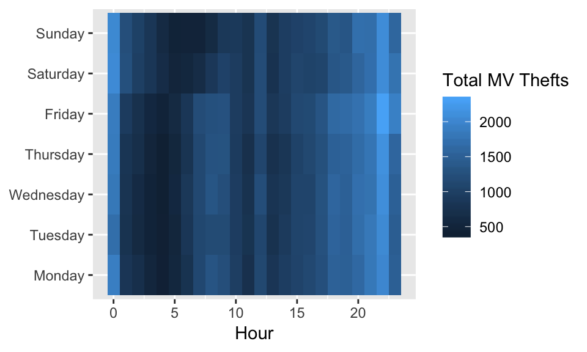

```r
ggplot(DayHourCounts, aes(x = Hour, y = Var1)) + geom_tile(aes(fill = Freq)) + scale_fill_gradient(name="Total MV Thefts") + theme(axis.title.y = element_blank())
```

Change the color scheme ie. `low="white", high="red"`

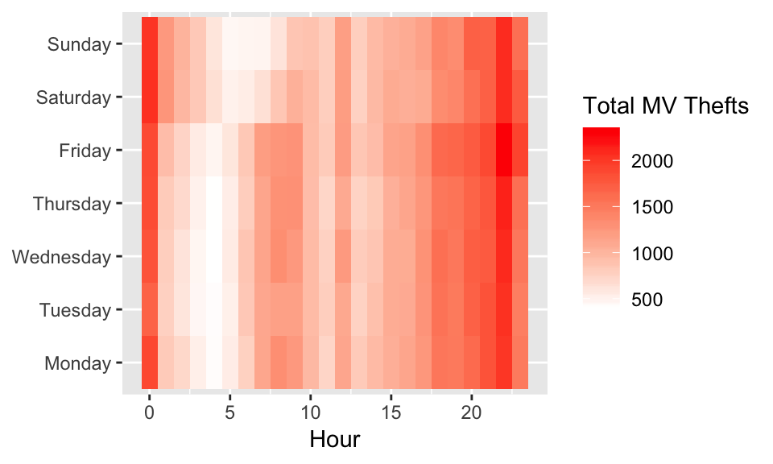

```r
ggplot(DayHourCounts, aes(x = Hour, y = Var1)) + geom_tile(aes(fill = Freq)) + scale_fill_gradient(name="Total MV Thefts", low="white", high="red") + theme(axis.title.y = element_blank())
```

##### Video 5 - Maps

Install and load two new packages

```r
#install.packages("maps")
#install.packages("ggmap")
library(maps)
library(ggmap)
```

Load a map of Chicago into R

```r
#chicago = get_map(location = "chicago", zoom = 11)
#ggmap(chicago)
```

Round our latitude and longitude to 2 digits of accuracy, and create a crime counts data frame for each area

```r
LatLonCounts = as.data.frame(table(round(mvt$Longitude,2), round(mvt$Latitude,2)))
str(LatLonCounts)
```

```
## 'data.frame':    1638 obs. of  3 variables:
##  $ Var1: Factor w/ 42 levels "-87.93","-87.92",..: 1 2 3 4 5 6 7 8 9 10 ...
##  $ Var2: Factor w/ 39 levels "41.64","41.65",..: 1 1 1 1 1 1 1 1 1 1 ...
##  $ Freq: int  0 0 0 0 0 0 0 0 0 0 ...
```

Convert our Longitude and Latitude variable to numbers

```r
LatLonCounts$Long = as.numeric(as.character(LatLonCounts$Var1))
LatLonCounts$Lat = as.numeric(as.character(LatLonCounts$Var2))
```

#### Quick Question

In the previous video, our heatmap was plotting squares out in the water, which seems a little strange. We can fix this by removing the observations from our data frame that have Freq = 0.

Take a subset of LatLonCounts, only keeping the observations for which Freq > 0, and call it LatLonCounts2.

If you redo the heatmap from the end of Video 5, using LatLonCounts2 instead of LatLonCounts, then you should no longer see any squares out in the water, or in any areas where there were no motor vehicle thefts.

How many observations did we remove? (You do not need to use the heatmap to answer this question)

```r
sum(LatLonCounts$Freq<=0)
```

```
## [1] 952
```